# library_explore

Lucius Bynum

9/21/2017

# Honnold Wireless Data

## Data Dictionary

- MACID: (hashed) a unique id every network device has. 50:CC:F8:80:39:4D is my (old) cellphone
- UUID: (hashed) a unique hashed user id
- Campus: 7C campus abbreviations, e.g. HMC
- Device Name: name given to the wireless access point: CUC-HON-1-N-CAFE
- Folder: Like Name, a hierarchical representation of the access point used in the configuration: Top > CUC > Honold Mudd Library > First Floor
- Device Location: Text description of the location: Honnold Cafe
- Connect Year: year in which a connection was initiated: 2016
- Connect Month: month in which a connection was initiated: 1
- Connect Day: day in which a connection was initiated: 3
- Connect Hour: hour in which a connection was initiated (24h): 15
- Connect Day of Week: number of the day in week in which a connection was initiated: 6
- Connect Day of Year: number of the day in year in which a connection was initiated: 3
- Total Traffic (MB): megabytes of data that passed through the connection: 23.56
- AOS: text description of the mobile device’s operationg system: OS X Manufacturer: the name of the device manufacturer: Apple

```r
wireless_data_path <- 'HMC\ Math\ 158/wireless/2016FallSemWireless.tsv'
ezproxy_data_path <- 'HMC\ Math\ 158/ezproxy/'

wireless <- read.delim(wireless_data_path, header = TRUE, sep = '\t')
wireless[wireless == '-'] <- NA
```

Explore.

```r
str(wireless)
```

```
## 'data.frame':    186543 obs. of  36 variables:
##  $ MACID            : Factor w/ 13288 levels "0005914410553507aedc49f38aad662a4cd782d5d6a767e03878093993a305da",..: 10024 9961 11391 11291 11291 10935 11391 2749 3054 3070 ...
##  $ UUID             : Factor w/ 6858 levels "","-","00011481d05283c8f669178ed2cf9dc226f7e8847b21d899bd43640ca0779988",..: NA 5151 1455 NA NA 2835 1455 NA NA 3043 ...
##  $ campus           : Factor w/ 34 levels "","-","bry","cam",..: NA 5 26 NA NA 26 26 NA NA 5 ...
##  $ role             : Factor w/ 15 levels "","-","0","authenticated",..: NA 10 10 8 NA 10 NA NA 8 10 ...
##  $ WAPID            : Factor w/ 33 levels "","0","CUC-HON-1-E-ELEVATOR",..: 17 17 33 20 20 20 20 27 27 14 ...
##  $ folder           : Factor w/ 7 levels "","0","Cafe",..: 7 7 7 7 7 7 7 4 4 6 ...
##  $ location         : Factor w/ 16 levels "","-","0","Fourth Floor",..: NA NA 16 14 14 14 14 12 12 8 ...
##  $ connect_year     : Factor w/ 1951 levels "","0","2016",..: 3 3 3 3 3 3 3 3 3 3 ...
##  $ connect_month    : Factor w/ 1175 levels "","-","0","10",..: 8 8 8 8 8 8 8 8 8 8 ...
##  $ connect_day      : Factor w/ 363 levels "","0","0 mins",..: 232 232 232 232 232 232 232 232 232 232 ...
##  $ connect_hour     : num  13 11 13 17 17 13 12 14 13 16 ...
##  $ connect_minute   : num  9 58 8 20 5 37 58 31 33 5 ...
##  $ connect_dow      : num  6 6 6 6 6 6 6 6 6 6 ...
##  $ connect_doy      : num  213 213 213 213 213 213 213 213 213 213 ...
```

[output cut: 22 more lines]

```r
names(wireless)
```

```
##  [1] "MACID"             "UUID"              "campus"
##  [4] "role"              "WAPID"             "folder"
##  [7] "location"          "connect_year"      "connect_month"
## [10] "connect_day"       "connect_hour"      "connect_minute"
## [13] "connect_dow"       "connect_doy"       "DST"
## [16] "disconnect_month"  "disconnect_day"    "disconnect_year"
## [19] "disconnect_hour"   "disconnect_minute" "duration_mins"
## [22] "bytes"             "bytesIn"           "bytesOut"
## [25] "avgKbps"           "AvgSigDBM"         "avgSigQual"
## [28] "vendor"            "radioMode"         "SSID"
## [31] "AOSdev"            "manuf"             "make"
## [34] "model"             "OSdev"             "Osdetail"
```

# EZProxy Data

Get the data.

```r
filelist = paste0(ezproxy_data_path, list.files(ezproxy_data_path, '*.tsv'))
is_a_ccl_file <- endsWith(filelist, 'hashed.tsv')
ccl_files <- filelist[is_a_ccl_file]
spu_files <- filelist[!is_a_ccl_file]
spu <- lapply(spu_files, function(x) read.delim(x, header = TRUE, sep = '\t'))
ccl <- lapply(ccl_files, function(x) read.delim(x, header = TRUE, sep = '\t'))
```

Concatenate the separate files, making sure column names are all aligned the same way.

```r
spu <- do.call(rbind, lapply(spu, function(x) x[match(names(spu[[1]]), names(x))]))
ccl <- do.call(rbind, lapply(ccl, function(x) x[match(names(ccl[[1]]), names(x))]))
```

## CCL (EZProxy Report) Data Dictionary

- hashed user id: a unique identifier for a user e.g. * f7cbed2a86c711b4e28d13f74c40acf9f2a85a61db354bd8aa22dd1f944735c8
- campus: e.g. pomona
- session start datetime: e.g. 2016-07-07 15:39:24
- session end datetime: e.g. 2016-07-07 18:57:32
- session id: a unique identifier per ezproxy session e.g. oXFj5X88FvnsWrI
- ip address: (subnet only) e.g. 66.17.192

### IP Address Subnets at Claremont

134.173.* belong to the Claremont Colleges.

The third octet values are assigned as follows:

- 8-15 Claremont SSID Wireless
- 24-31 Claremont SSID Wireless
- 32-63 HMC
- 64-95 Pomona
- 96-103 KGI
- 112-123 Pitzer
- 124-127 CUC - Legacy
- 128-135 CUC
- 140-141 Keck Science
- 144-159 Scripps
- 160-191 CMC
- 192-223 CINE Wireless
- 224-239 CGU
- 244-245 VPN Interior (non-Administrative)

## CCL Data

```r
names(ccl)
```

```
## [1] "uuid"     "session"  "campus"   "datetime" "ipSubnet"
```

```r
str(ccl)
```

```
## 'data.frame':    133534 obs. of  5 variables:
##  $ uuid    : Factor w/ 9304 levels "0008e9450111a8ef717e2e32e9dda5333f5b8299cbf75f69920f6ba709597f98",..: 2604 1959 913 299 299 299 299 845 845 2339 ...
##  $ session : Factor w/ 133534 levels "00qovRmeMNVkVgE",..: 8601 7962 2022 3487 9062 3667 1060 6927 2305 11734 ...
##  $ campus  : Factor w/ 9 levels "cgu","cmc","cuc",..: 7 8 8 9 9 9 9 8 8 8 ...
##  $ datetime: Factor w/ 133495 levels "2016-05-01 00:00:16 2016-05-01 02:00:42",..: 11420 3610 8560 225 2694 3497 3386 13612 4902 9428 ...
##  $ ipSubnet: Factor w/ 11045 levels "1.211.69","1.52.109",..: 1103 591 591 565 197 197 197 464 596 600 ...
```

## SPU Data Dictionary

- session: unique session id. foreign key for report
- scheme: typically the transport protocol, e.g. http
- subdomain: aka host, e.g. ‘www’
- domain: often the name of the service, e.g. lexisnexis
- tld: The final portion of a Uniform Resource Locator, e.g. ‘com’
- path: file path to the requested resource
- query: often the requested resource, or if there’s a search query it should be here
- fragment: leftovers, e.g. preferences, tracking crap, etc.

## SPU Data

```r
names(spu)
```

```
## [1] "session"   "scheme"    "subdomain" "domain"    "tld"       "path"
## [7] "query"     "fragment"
```

```r
str(spu)
```

```
## 'data.frame':    529095 obs. of  8 variables:
##  $ session  : Factor w/ 227893 levels "00j9WUlbRnG1Cdr",..: 4781 12635 12928 5431 7075 12635 6346 6346 6346 6346 ...
##  $ scheme   : Factor w/ 2 levels "http","https": 1 2 2 1 1 2 1 1 1 1 ...
##  $ subdomain: Factor w/ 1337 levels "","1.next","a.next",..: 225 74 74 405 405 74 398 398 458 458 ...
##  $ domain   : Factor w/ 512 levels "","aasa","abc-clio",..: 186 154 154 79 79 154 81 81 187 187 ...
##  $ tld      : Factor w/ 49 levels "ajplegacy","ca",..: 5 13 13 5 5 13 5 5 5 5 ...
##  $ path     : Factor w/ 52154 levels "/","/(S(00vpijbu4a2upr0vdw5ksk0q))/Reader.aspx",..: 1054 1935 1935 2462 2462 1935 2475 1689 2984 2984 ...
##  $ query    : Factor w/ 164166 levels "","_a=ChgyMDE2MDEwNTIxMDA0NTEzOToxMjU3MzgSBjEwNjcwMxoKT05FX1NFQVJDSCIOMTMyLjE3NC4yNTUuODYqBjY4NjUwODIKMTQ2NjE3MjEw"| __truncated__,..: 1 9871 9704 6905 6592 9961 3059 4883 3577 3619 ...
##  $ fragment : chr  NA NA NA NA ...
```

```r
nrow(spu)
```

```
## [1] 529095
```

```r
nrow(ccl)
```

```
## [1] 133534
```

# Combined EZProxy Data

```r
ccl_spu <- preprocess_ezproxy_data()
ccl2 <- preprocess_ezproxy_data_ccl()
ccl_clean <- preprocess_ezproxy_data_ccl()
levels(ccl_spu$campus) <- c('cgu', 'cmc', 'cuc', 'hmc', 'kec', 'kgi', 'pit', 'pom', 'scr', 'kec', 'pit', 'pom', 'scr')
levels(ccl2$campus) <- c('cgu', 'cmc', 'cuc', 'hmc', 'kec', 'kgi', 'pit', 'pom', 'scr', 'kec', 'pit', 'pom', 'scr')
levels(ccl_clean$campus) <- c('cgu', 'cmc', 'cuc', 'hmc', 'kec', 'kgi', 'pit', 'pom', 'scr', 'kec', 'pit', 'pom', 'scr')
```

```r
helper <- function(x) {
  x <- toString(x)
  if (startsWith(x, '134.173')) {
    finalPiece = strtoi(strsplit(x, '\\.')[[1]][3])
    if (finalPiece == 244 || finalPiece == 245) {
      'vpn'
    } else if ((finalPiece >= 8 && finalPiece <= 15) || (finalPiece >= 24 && finalPiece <= 31)){
      'ssid'
    } else if (finalPiece >= 32 && finalPiece <= 63) {
      'hmc'
    } else if (finalPiece >= 64 && finalPiece <= 95) {
      'pom'
    } else if (finalPiece >= 96 && finalPiece <= 103) {
      'kgi'
    } else if (finalPiece >= 112 && finalPiece <= 123) {
      'pit'
    } else if (finalPiece >= 124 && finalPiece <= 135) {
      'cuc'
    } else if (finalPiece == 140 || finalPiece == 141) {
      'keck'
    } else if (finalPiece >= 144 && finalPiece <= 159) {
      'scr'
    } else if (finalPiece >= 160 && finalPiece <= 191) {
      'cmc'
    } else if (finalPiece >= 192 && finalPiece <= 223) {
      'cine'
    } else if (finalPiece >= 224 && finalPiece <= 239) {
      'cgu'
    } else if (finalPiece >= 244 && finalPiece <= 245) {
      'vpn'
    } else {
      'on'
    }
  } else {
    'off'
  }
}

helper2 <- function(x) {
  if (x == 'off') {
    'off'
  } else if (x == 'vpn') {
    'vpn'
  } else {
    'on'
  }
}
nrow(ccl_clean)
```

```
## [1] 211813
```

```r
locationCol2 <- sapply(ccl_clean$ipSubnet, helper)
locationCol <- sapply(ccl_spu$ipSubnet, helper)
ccl_spu["location"] <- as.factor(locationCol)
ccl_clean["location"] <- as.factor(locationCol2)
onOffCol <- sapply(ccl_spu$location, helper2)
onOffCol2 <- sapply(ccl_clean$location, helper2)
ccl_spu["onOff"] <- as.factor(onOffCol)
ccl_clean["onOff"] <- as.factor(onOffCol2)
nrow(ccl_spu)
```

```
## [1] 489565
```

```r
ncol(ccl_spu)
```

```
## [1] 16
```

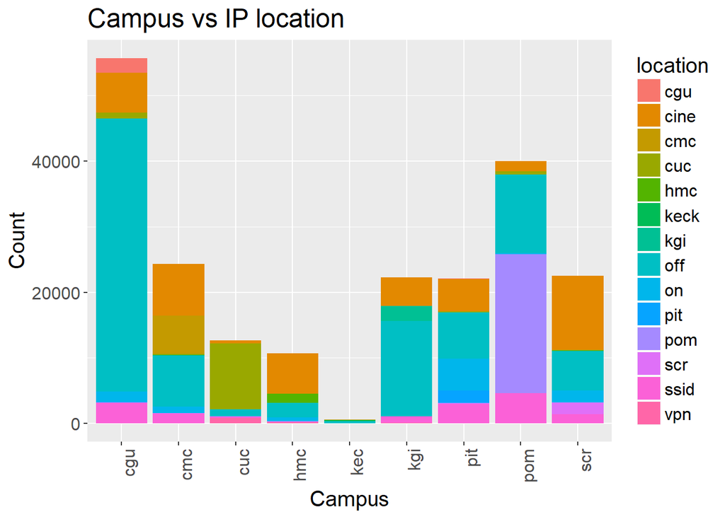

```r
ccl_spu %>% select(campus, location, session) %>%  group_by(campus, location) %>% summarize(counts = n_distinct(session)) %>% ggplot(aes(x = campus, y = counts, fill = location)) + geom_bar(stat='identity') + ggtitle("Campus vs IP location") + xlab("Campus") + ylab("Count")+ theme(text=element_text(size=15), axis.text.x=element_text(angle=90, hjust=1))
```

```r
domainCounts <- ccl_spu %>% group_by(domain) %>% summarize(counts=n())
names(domainCounts)
```

```
## [1] "domain" "counts"
```

```r
domainCounts <- domainCounts %>% arrange(desc(domainCounts$counts))
domains <- domainCounts$domain[1:20]
domains
```

```
##  [1] ebscohost        oclc             ebrary           proquest
##  [5] jstor            sciencedirect    eblib            doi
##  [9] wiley            sagepub          tandfonline      springer
## [13] isiknowledge     google           galegroup        lexisnexis
## [17] jhu              oxfordjournals   cambridge        lwwhealthlibrary
## 512 Levels:  aasa abc-clio accessible accesspharmacy acm acrl ... utoronto
```

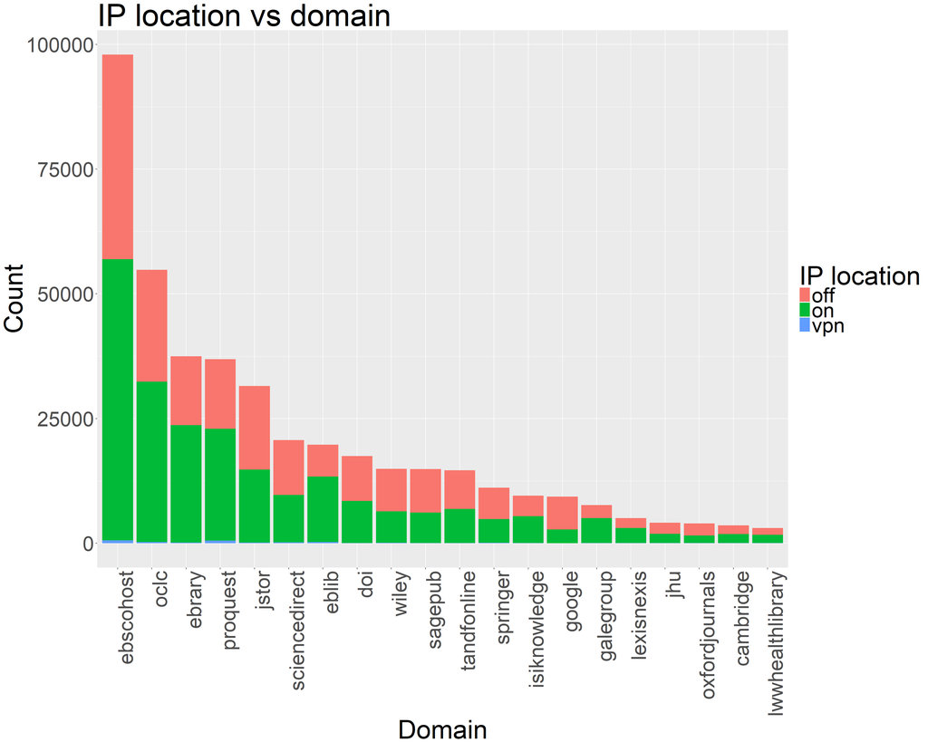

```r
summary <- ccl_spu %>% select(campus, location, session, domain, onOff) %>% group_by(domain, onOff) %>% summarize(counts = n())
summary <- summary[summary$domain %in% domains,]
summary %>% ggplot(aes(x=reorder(domain, -counts), y=counts, fill=onOff)) + geom_bar(stat='identity') + ggtitle("IP location vs domain") + xlab("Domain") + ylab("Count") + theme(text=element_text(size=40), axis.text.x=element_text(angle=90, hjust=1)) + guides(fill=guide_legend(title="IP location"))
```

```r
domainCounts <- ccl_spu %>% group_by(domain) %>% summarize(counts=n())
names(domainCounts)
```

```
## [1] "domain" "counts"
```

```r
domainCounts <- domainCounts %>% arrange(desc(domainCounts$counts))
domains <- domainCounts$domain[1:20]
domains
```

```
##  [1] ebscohost        oclc             ebrary           proquest
##  [5] jstor            sciencedirect    eblib            doi
##  [9] wiley            sagepub          tandfonline      springer
## [13] isiknowledge     google           galegroup        lexisnexis
## [17] jhu              oxfordjournals   cambridge        lwwhealthlibrary
## 512 Levels:  aasa abc-clio accessible accesspharmacy acm acrl ... utoronto
```

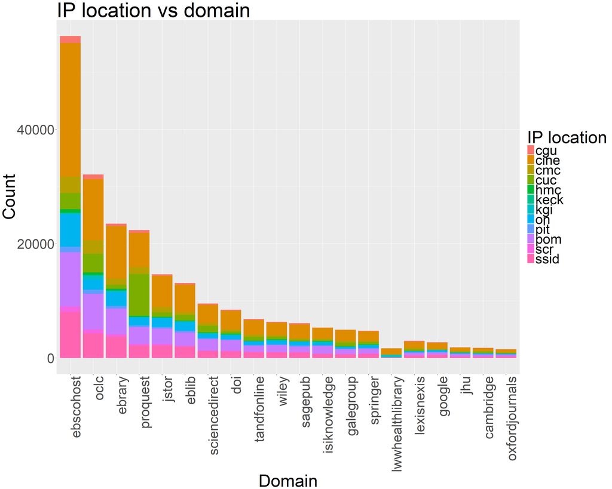

```r
ccl_spu_filtered <- ccl_spu[ccl_spu$onOff == 'on',]
summary <- ccl_spu_filtered %>% select(campus, location, session, domain, onOff) %>% group_by(domain, location) %>% summarize(counts = n())
summary <- summary[summary$domain %in% domains,]
summary %>% ggplot(aes(x=reorder(domain, -counts), y=counts, fill=location)) + geom_bar(stat='identity')  + ggtitle("IP location vs domain") + xlab("Domain") + ylab("Count") + theme(text=element_text(size=40), axis.text.x=element_text(angle=90, hjust=1)) + guides(fill=guide_legend(title="IP location"))
```

```r
ccl_clean <- ccl_clean[ccl_clean$session_duration_mins < 24*60, ]
ccl_clean <- ccl_clean[ccl_clean$session_duration_mins > 122, ]
ccl_clean <- na.omit(ccl_clean)
ccl2 <- ccl2[ccl2$session_duration_mins < 750,]
```

```r
counts <- count(ccl_clean %>% filter(campus == 'pom'), onOff)
counts
```

```
## # A tibble: 3 x 2
##    onOff     n
##   <fctr> <int>
## 1    off  6943
## 2     on 15862
## 3    vpn     1
```

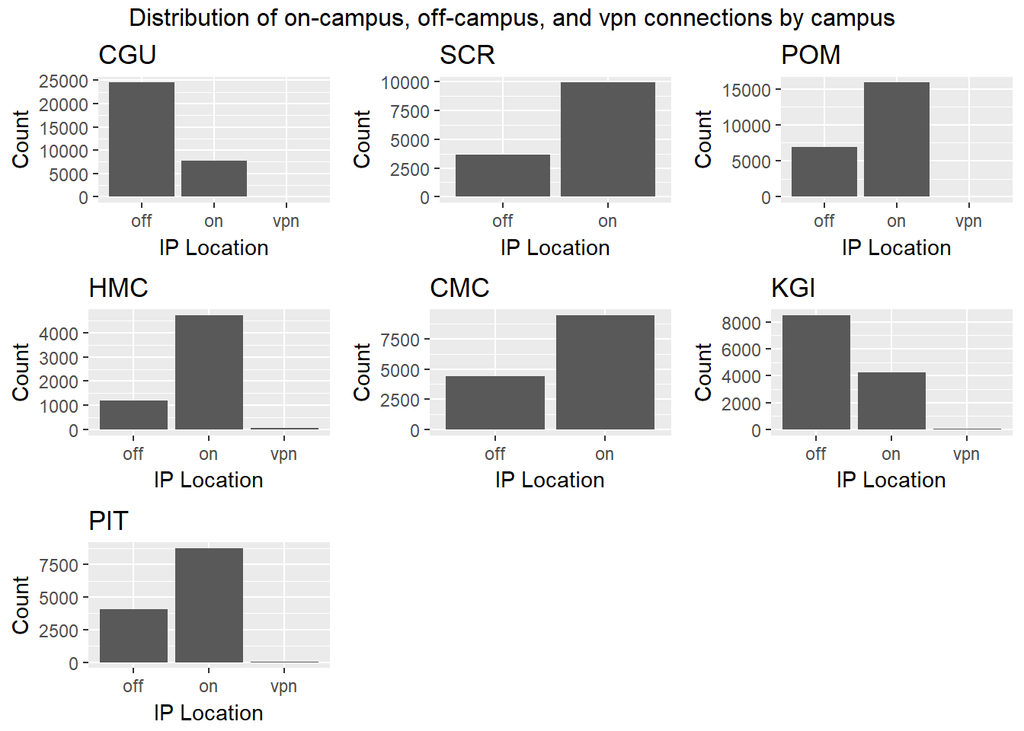

```r
cgu <- ccl_clean %>% filter(campus == 'cgu') %>% group_by(onOff) %>% summarize(count = n()) %>% ggplot(aes(x=onOff, y=count)) + geom_bar(stat="identity") + ggtitle("CGU") + xlab("IP Location") + ylab("Count")
scr <- ccl_clean %>% filter(campus == 'scr') %>% group_by(onOff) %>% summarize(count = n()) %>% ggplot(aes(x=onOff, y=count)) + geom_bar(stat="identity") + ggtitle("SCR") + xlab("IP Location") + ylab("Count")
pom <- ccl_clean %>% filter(campus == 'pom') %>% group_by(onOff) %>% summarize(count = n()) %>% ggplot(aes(x=onOff, y=count)) + geom_bar(stat="identity") + ggtitle("POM") + xlab("IP Location") + ylab("Count")
hmc <- ccl_clean %>% filter(campus == 'hmc') %>% group_by(onOff) %>% summarize(count = n()) %>% ggplot(aes(x=onOff, y=count)) + geom_bar(stat="identity") + ggtitle("HMC") + xlab("IP Location") + ylab("Count")
cmc <- ccl_clean %>% filter(campus == 'cmc') %>% group_by(onOff) %>% summarize(count = n()) %>% ggplot(aes(x=onOff, y=count)) + geom_bar(stat="identity") + ggtitle("CMC") + xlab("IP Location") + ylab("Count")
kgi <- ccl_clean %>% filter(campus == 'kgi') %>% group_by(onOff) %>% summarize(count = n()) %>% ggplot(aes(x=onOff, y=count)) + geom_bar(stat="identity") + ggtitle("KGI") + xlab("IP Location") + ylab("Count")
pit <- ccl_clean %>% filter(campus == 'pit') %>% group_by(onOff) %>% summarize(count = n()) %>% ggplot(aes(x=onOff, y=count)) + geom_bar(stat="identity") + ggtitle("PIT") + xlab("IP Location") + ylab("Count")
grid.arrange(cgu, scr, pom, hmc, cmc, kgi, pit, ncol=3, top="Distribution of on-campus, off-campus, and vpn connections by campus")
```

```r
par(mar=c(4,6,2,2))
names(ccl_clean)
```

```
## [1] "uuid"                  "campus"                "session"
## [4] "ipSubnet"              "session_start"         "session_end"
## [7] "session_duration_mins" "location"              "onOff"
```

```r
mod <- lm(session_duration_mins ~ onOff, ccl_clean)
mod2 <- lm(session_duration_mins ~ location, ccl_clean)
summary(mod)
```

```
##
## Call:
## lm(formula = session_duration_mins ~ onOff, data = ccl_clean)
##
## Residuals:
##     Min      1Q  Median      3Q     Max
##  -62.73  -44.59  -27.43   18.96 1257.61
##
## Coefficients:
##             Estimate Std. Error t value Pr(>|t|)
## (Intercept) 172.2924     0.3025 569.563  < 2e-16 ***
## onOffon      -0.6151     0.4110  -1.497    0.134
## onOffvpn     12.4710     2.8780   4.333 1.47e-05 ***
## ---
## Signif. codes:  0 '***' 0.001 '**' 0.01 '*' 0.05 '.' 0.1 ' ' 1
##
## Residual standard error: 70.22 on 118216 degrees of freedom
## Multiple R-squared:  0.0001874,  Adjusted R-squared:  0.0001705
## F-statistic: 11.08 on 2 and 118216 DF,  p-value: 1.548e-05
```

```r
summary(mod2)
```

```
##
## Call:
## lm(formula = session_duration_mins ~ location, data = ccl_clean)
##
## Residuals:
##     Min      1Q  Median      3Q     Max
##  -62.73  -44.41  -27.18   18.82 1257.61
##
## Coefficients:
##              Estimate Std. Error t value Pr(>|t|)
## (Intercept)   165.511      1.937  85.462  < 2e-16 ***
## locationcine    6.350      1.987   3.196 0.001393 **
## locationcmc     5.344      2.294   2.329 0.019837 *
## locationcuc     3.628      2.298   1.579 0.114361
## locationhmc     3.931      3.224   1.219 0.222771
## locationkeck  -23.582      6.199  -3.804 0.000143 ***
## locationkgi     1.465      2.744   0.534 0.593362
## locationoff     6.781      1.960   3.459 0.000542 ***
## locationon      9.686      2.145   4.516 6.29e-06 ***
## locationpit    -3.115      2.937  -1.061 0.288864
## locationpom     5.830      2.039   2.859 0.004255 **
## locationscr   -10.412      2.950  -3.530 0.000416 ***
## locationssid   10.213      2.075   4.921 8.61e-07 ***
## locationvpn    19.252      3.454   5.574 2.50e-08 ***
## ---
## Signif. codes:  0 '***' 0.001 '**' 0.01 '*' 0.05 '.' 0.1 ' ' 1
##
## Residual standard error: 70.18 on 118205 degrees of freedom
## Multiple R-squared:  0.001578,   Adjusted R-squared:  0.001468
## F-statistic: 14.37 on 13 and 118205 DF,  p-value: < 2.2e-16
```

```r
anova(mod)
```

```
## Analysis of Variance Table
##
## Response: session_duration_mins
##               Df    Sum Sq Mean Sq F value    Pr(>F)
## onOff          2    109244   54622  11.077 1.548e-05 ***
## Residuals 118216 582931611    4931
## ---
## Signif. codes:  0 '***' 0.001 '**' 0.01 '*' 0.05 '.' 0.1 ' ' 1
```

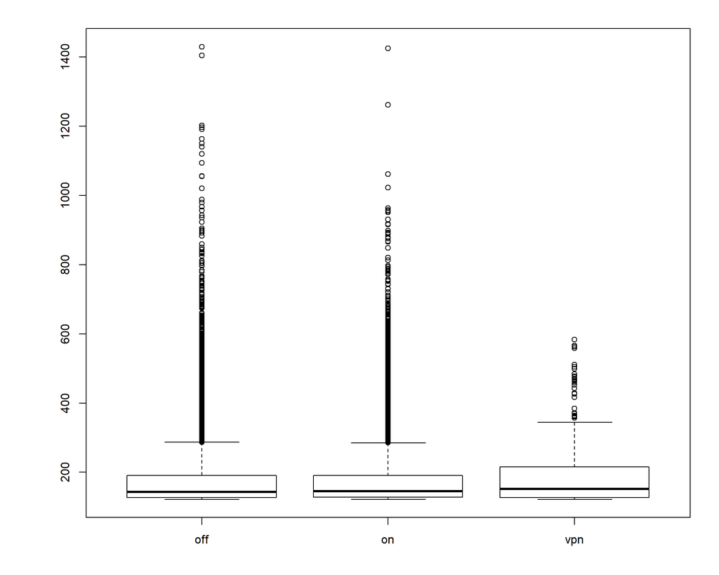

```r
plot(ccl_clean$onOff, ccl_clean$session_duration_mins)
```

```r
filtered <- ccl_clean %>% filter(location %in% c('cgu', 'cine', 'cmc', 'hmc', 'kgi', 'pit', 'pom', 'scr'))
(tci <- TukeyHSD(aov(session_duration_mins ~ onOff, ccl_clean)))
```

```
##   Tukey multiple comparisons of means
##     95% family-wise confidence level
##
## Fit: aov(formula = session_duration_mins ~ onOff, data = ccl_clean)
##
## $onOff
##               diff       lwr        upr     p adj
## on-off  -0.6151457 -1.578294  0.3480028 0.2923949
## vpn-off 12.4709701  5.725893 19.2160473 0.0000437
## vpn-on  13.0861158  6.346795 19.8254370 0.0000159
```

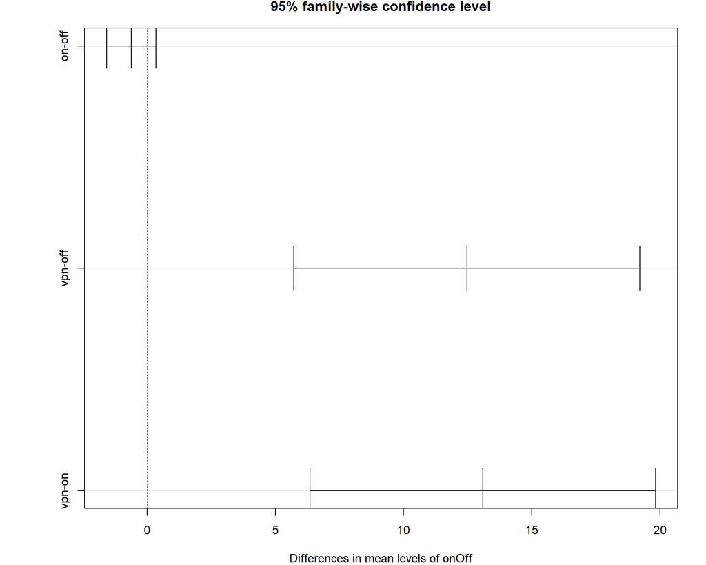

```r
plot(tci)
```

```r
mod <- lm(session_duration_mins ~ location, ccl_clean)
anova(mod)
```

```
## Analysis of Variance Table
##
## Response: session_duration_mins
##               Df    Sum Sq Mean Sq F value    Pr(>F)
## location      13    919823   70756  14.368 < 2.2e-16 ***
## Residuals 118205 582121031    4925
## ---
## Signif. codes:  0 '***' 0.001 '**' 0.01 '*' 0.05 '.' 0.1 ' ' 1
```

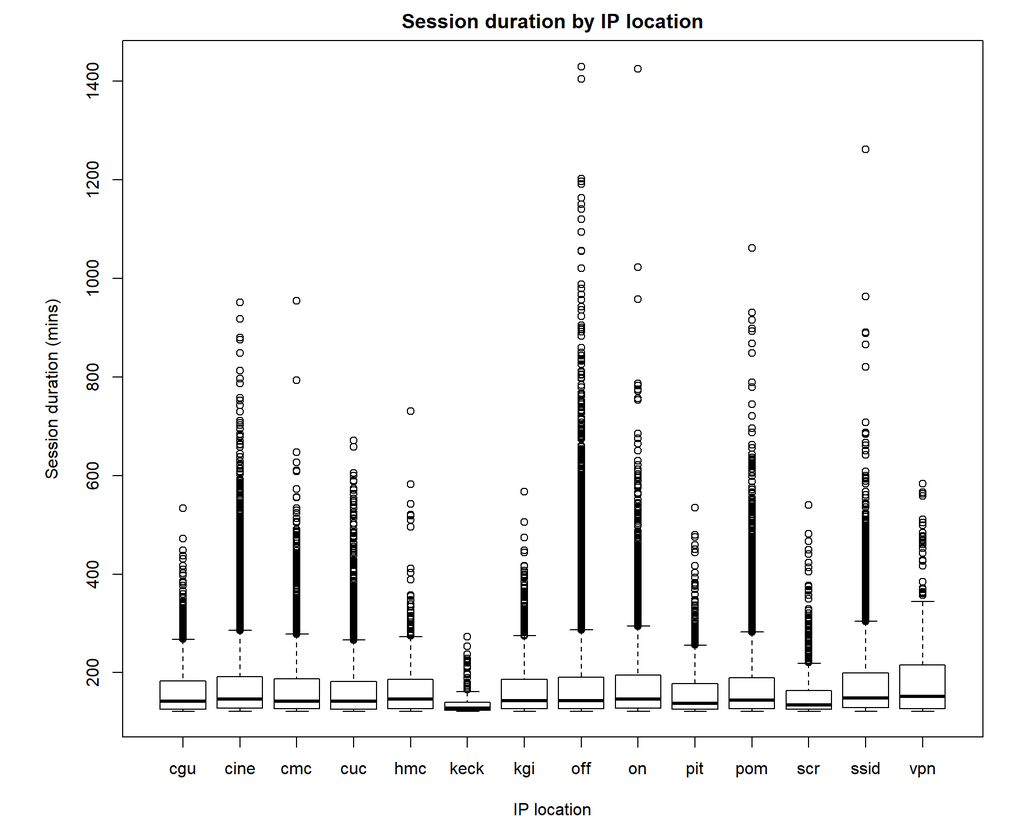

```r
plot(ccl_clean$location, ccl_clean$session_duration_mins, main="Session duration by IP location", xlab="IP location", ylab="Session duration (mins)")
```

```r
(tci <- TukeyHSD(aov(session_duration_mins ~ location, filtered)))
```

```
##   Tukey multiple comparisons of means
##     95% family-wise confidence level
##
## Fit: aov(formula = session_duration_mins ~ location, data = filtered)
##
## $location
##                 diff           lwr         upr     p adj
## cine-cgu   6.3500904  6.697597e-01  12.0304211 0.0161563
## cmc-cgu    5.3443927 -1.214988e+00  11.9037739 0.2085548
## hmc-cgu    3.9311730 -5.287458e+00  13.1498040 0.9019814
## kgi-cgu    1.4652836 -6.380241e+00   9.3108080 0.9992393
## pit-cgu   -3.1151625 -1.151245e+01   5.2821291 0.9516834
## pom-cgu    5.8300532 -7.035908e-04  11.6608100 0.0500536
## scr-cgu  -10.4120694 -1.884506e+01  -1.9790775 0.0045194
## cmc-cine  -1.0056977 -4.743969e+00   2.7325740 0.9923242
## hmc-cine  -2.4189174 -9.897711e+00   5.0598761 0.9772863
## kgi-cine  -4.8848068 -1.058581e+01   0.8161973 0.1568340
## pit-cine  -9.4652529 -1.590448e+01  -3.0260215 0.0002251
## pom-cine  -0.5200372 -2.744204e+00   1.7041300 0.9967777
## scr-cine -16.7621598 -2.324788e+01 -10.2764412 0.0000000
## hmc-cmc   -1.4132197 -9.579717e+00   6.7532775 0.9995393
## kgi-cmc   -3.8791091 -1.045640e+01   2.6981831 0.6286349
## pit-cmc   -8.4595552 -1.568611e+01  -1.2330051 0.0092604
## pom-cmc    0.4856605 -3.477450e+00   4.4487710 0.9999546
## scr-cmc  -15.7564621 -2.302447e+01  -8.4884589 0.0000000
## kgi-hmc   -2.4658894 -1.169727e+01   6.7654946 0.9926491
## pit-hmc   -7.0463355 -1.675101e+01   2.6583388 0.3511729
## pom-hmc    1.8988803 -5.694796e+00   9.4925566 0.9950983
## scr-hmc  -14.3432423 -2.407882e+01  -4.6076608 0.0002148
## pit-kgi   -4.5804461 -1.299174e+01   3.8308439 0.7192782
## pom-kgi    4.3647697 -1.486129e+00  10.2156684 0.3154024
## scr-kgi  -11.8773529 -2.032428e+01  -3.4304220 0.0005366
## pom-pit    8.9452157  2.372905e+00  15.5175265 0.0009672
## scr-pit   -7.2969069 -1.625865e+01   1.6648393 0.2092902
## scr-pom  -16.2421226 -2.285999e+01  -9.6242593 0.0000000
```

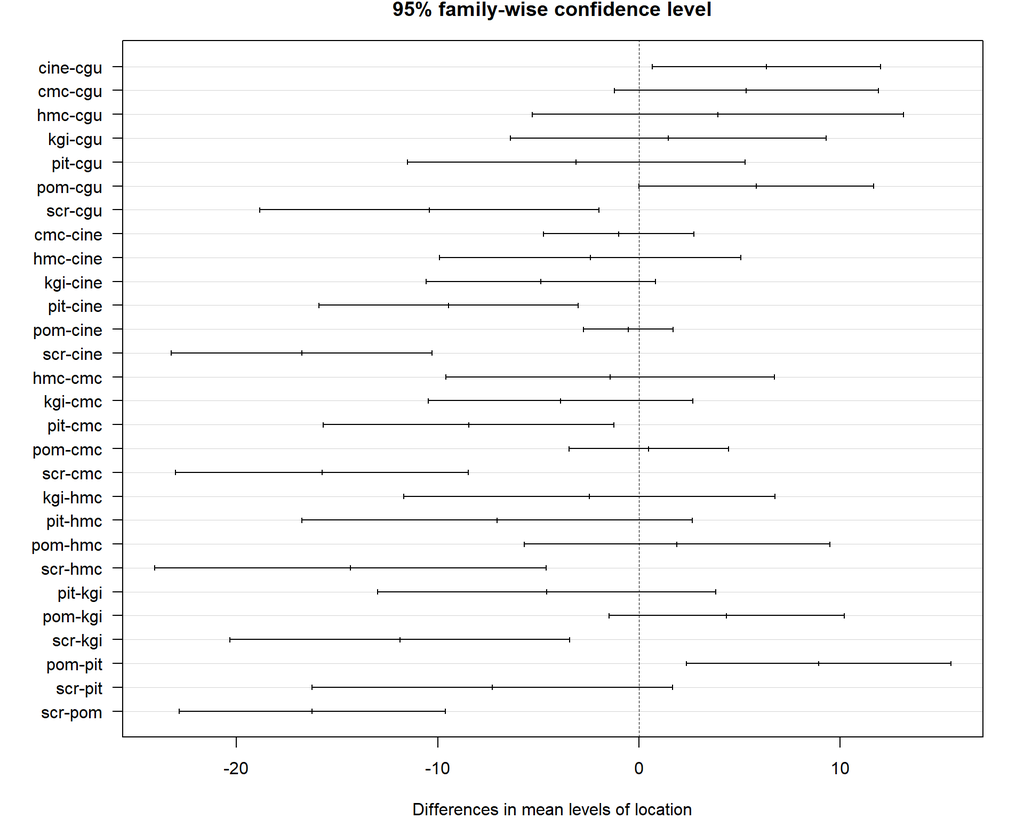

```r
plot(tci, las=1)
```

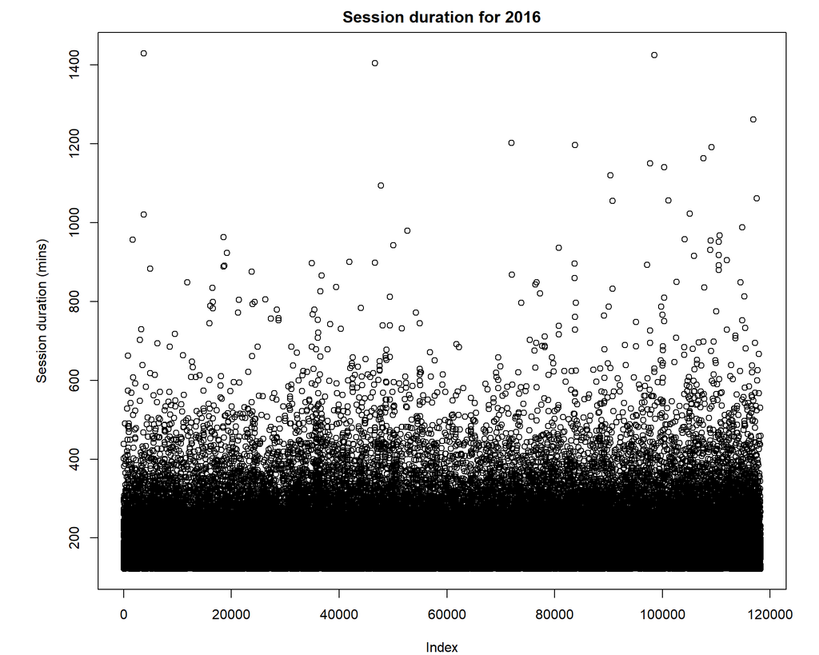

```r
plot(ccl_clean$session_duration_mins, main="Session duration for 2016", ylab="Session duration (mins)")
```

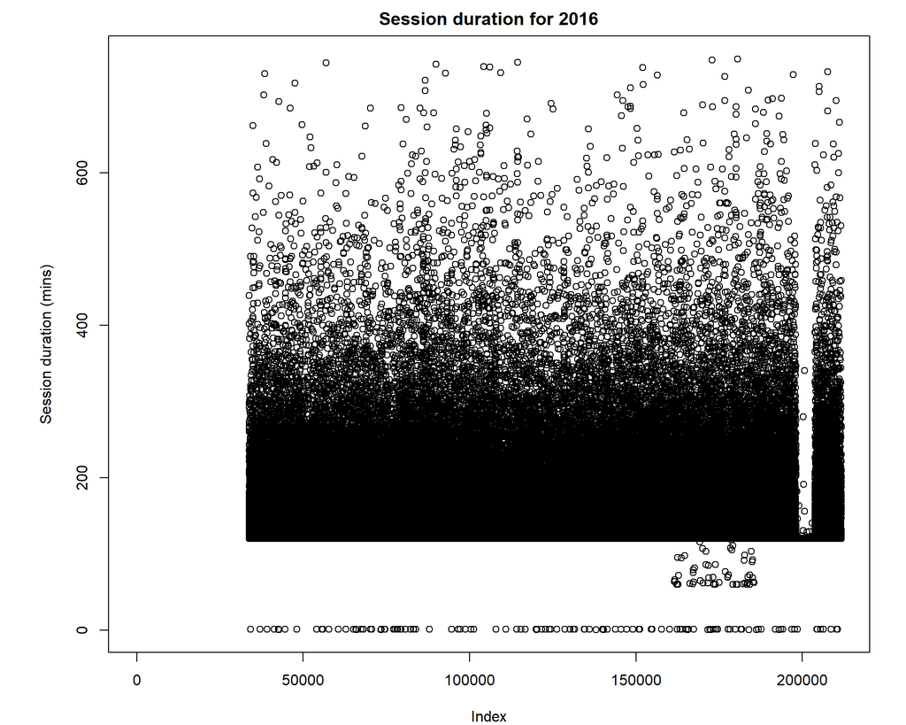

```r
plot(ccl2$session_duration_mins, main="Session duration for 2016", ylab="Session duration (mins)")
```

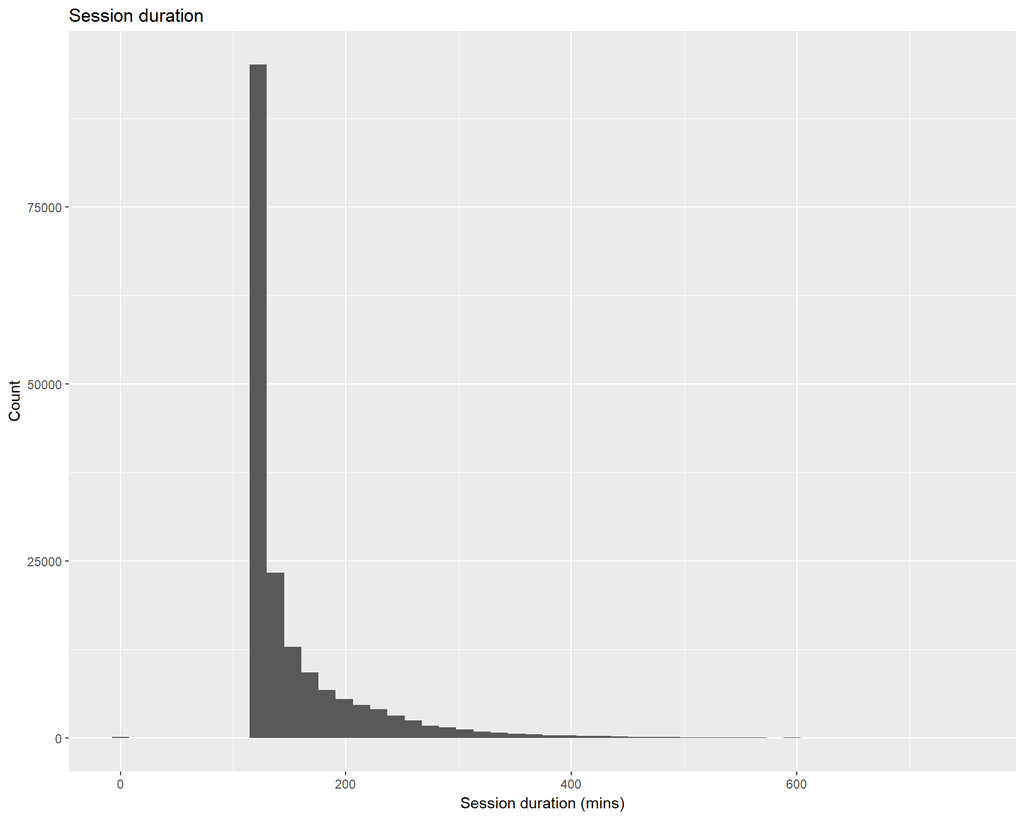

```r
ggplot(data=ccl2, aes(ccl2$session_duration_mins)) + geom_histogram(bins=50) + ggtitle("Session duration") + xlab("Session duration (mins)") + ylab("Count")
```